# Visualisation2

Nikita Zaitsev

2024-10-13

```r
hogwarts <- read_csv("data/hogwarts_2024.csv")
hogwarts %>% head()
```

```
## # A tibble: 6 × 60
##      id house    course sex   wandCore bloodStatus result Defence against the …¹
##   <dbl> <chr>     <dbl> <chr> <chr>    <chr>        <dbl>                  <dbl>
## 1     1 Ravencl…      4 fema… unicorn… half-blood      94                     73
## 2     2 Hufflep…      5 male  phoenix… half-blood      33                     38
## 3     3 Ravencl…      4 fema… dragon … half-blood     137                     52
## 4     4 Hufflep…      2 male  phoenix… half-blood      27                     50
## 5     5 Hufflep…      2 fema… phoenix… half-blood      67                     47
## 6     6 Gryffin…      6 male  phoenix… muggle-born    126                     44
## # ℹ abbreviated name: ¹`Defence against the dark arts exam`
## # ℹ 52 more variables: `Flying exam` <dbl>, `Astronomy exam` <dbl>,
## #   `Herbology exam` <dbl>, `Divinations exam` <dbl>, `Charms exam` <dbl>,
## #   `History of magic exam` <dbl>, `Arithmancy exam` <dbl>,
## #   `Care of magical creatures exam` <dbl>, `Muggle studies exam` <dbl>,
## #   `Study of ancient runes exam` <dbl>, `Transfiguration exam` <dbl>,
## #   `Potions exam` <dbl>, week_1 <dbl>, week_2 <dbl>, week_3 <dbl>, …
```

```r
hogwarts <- hogwarts %>%
  mutate(across(c(house, course, sex, wandCore, bloodStatus), ~ as.factor(.x)))

theme_custom <- theme(
    panel.background = element_rect(fill = "white"),
    plot.title = element_text(size = 30, hjust = 0.5),
    plot.subtitle = element_text(size = 25, hjust = 0.5),
    plot.caption = element_text(size = 15),
    strip.text = element_text(size = 20),
    axis.text = element_text(size = 20),
    axis.title = element_text(size = 25),
    legend.title = element_text(size = 25),
    legend.text = element_text(size = 20)
  )

house_colors <- c("Gryffindor" = "#C50000",
                  "Hufflepuff" = "#ECB939",
                  "Ravenclaw" = "#41A6D9",
                  "Slytherin" = "#1F5D25")
```

## Диаграммы рассеяния (скаттерплоты)

### Задание №1

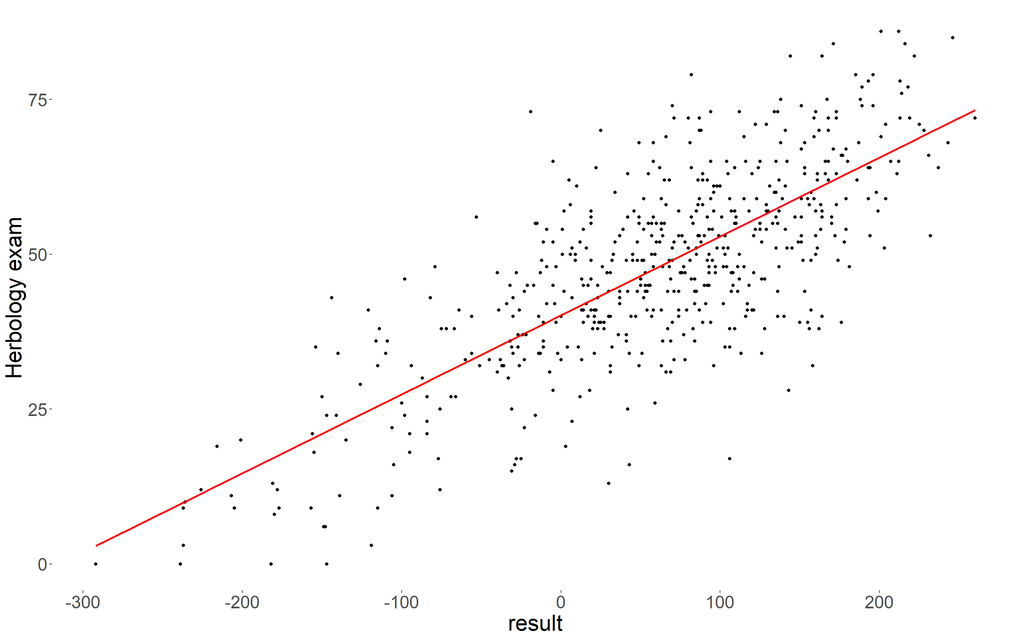

```r
hogwarts %>%
  ggplot(aes(x = result, y = `Herbology exam`))+
  geom_point()+
  geom_smooth(se = FALSE,
              method = 'lm',
              color = 'red')+
  theme_custom
```

**Интерпретация графика:** Можно заметить, что между данными переменными наблюдается положительная корреляция. То есть с ростом суммарного балла по всем экзаменам, растет и отдельный балл по травологии, что, собственно, и логично.

### Задание №2

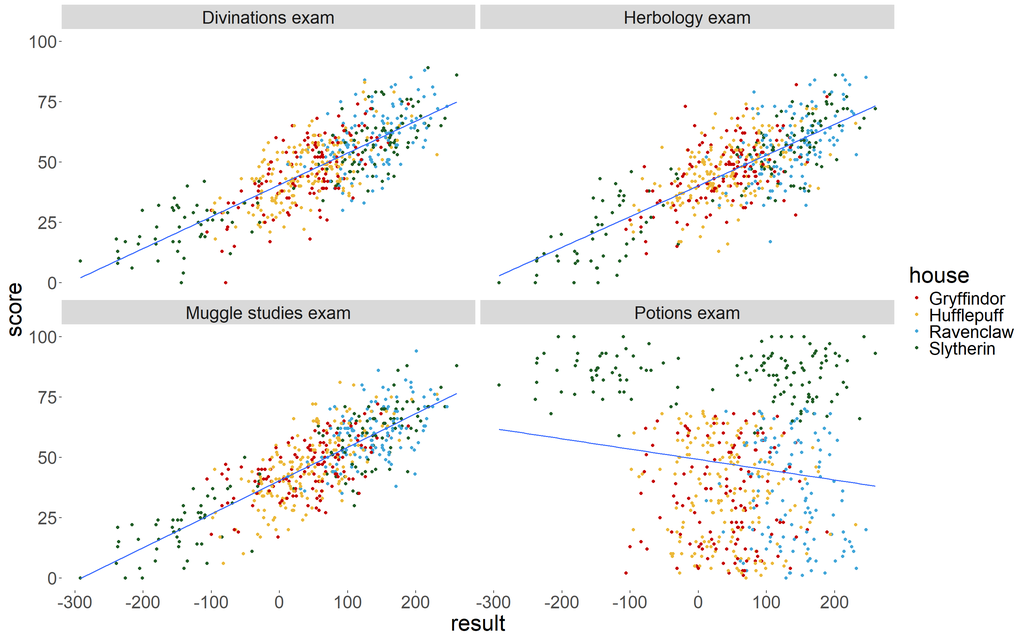

```r
hogwarts %>%
  pivot_longer(cols = c(`Herbology exam`, `Muggle studies exam`, `Divinations exam`, `Potions exam`), names_to = "exam", values_to = 'score') %>%
  ggplot(aes(x = result, y = score))+
  geom_point(aes(color = house))+
  geom_smooth(method = 'lm', se = FALSE, linewidth = 0.7)+
  scale_color_manual(values = house_colors)+
  theme_custom+
  facet_wrap(exam~.)
```

**Интерпретация графика:** Из графика можно заметить, что три из четырех переменных (оценки за экзамен) обладают положительной корреляцией с общим баллом студента за год. Однако в распределение оценок за экзамен по зельеварению вносят свои коррективы мальчики из Слизерина, которые имеют высокие оценки наравне с девочками из Слизерина за этот экзамен, однако плохо сдали другие экзамены, чем существенно занизили себе общий балл за год.

В общем, на всех 4 графиков можно заметить, что некоторые факультеты находятся выше и правее на графике, чем другие

### Задание №3

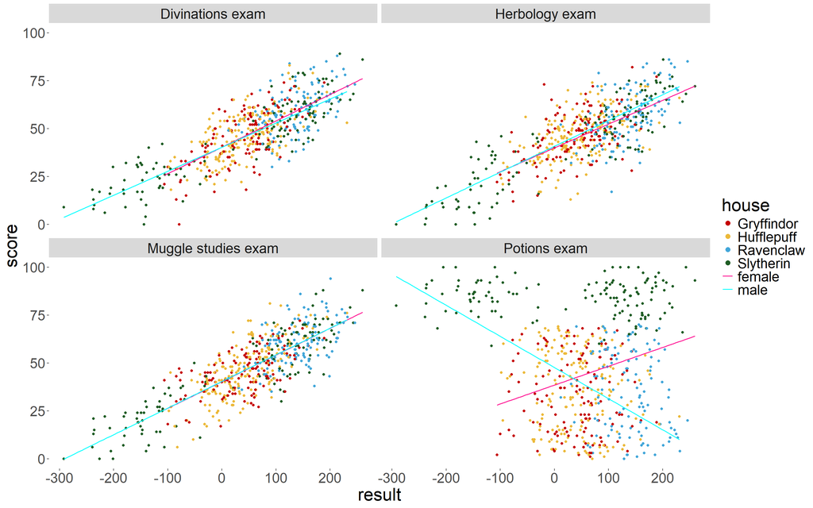

```r
hogwarts %>%
  pivot_longer(cols = c(`Herbology exam`, `Muggle studies exam`, `Divinations exam`, `Potions exam`), names_to = "exam", values_to = 'score') %>%
  ggplot(aes(x = result, y = score))+
  geom_point(aes(color = house))+
  geom_smooth(aes(color = sex), method = 'lm', se = FALSE, linewidth = 0.7)+
  scale_color_manual(values = c(house_colors, 'male' = 'cyan','female'='deeppink'))+
  theme_custom+
  guides(color = guide_legend(override.aes = list(size = 3)))+ #Этот момент, я честно признаюсь, подсмотрел в chatgpt, так как мне не понравился размер точек в легенде, а в базовой шпаргалке по ggplot найти не получилось
  facet_wrap(exam~.)
```

**Интерпретация графика:** За рамками визуализации домашней работы посмотрел зависимости от всех категориальных переменных. Мне показалось, что самая интересная связь по полу учеников. Можно заметить, что кроме зельеварения у всех экзаменов однонаправленная связь между общей оценкой и результатом за конкретный экзамен по полу. Однако у зельеварения очевидно, что вклад мальчиков слизеринцев вносит отрицательную корреляцию между переменными, о чем можно сделать вывод, что данная группа студентов существенно отличается от всех остальных (о статистически значимых отличиях пока не могу сказать, не хватает мозгов и знаний с: ).

## geom_col и вещи вокруг него

### Задание №1

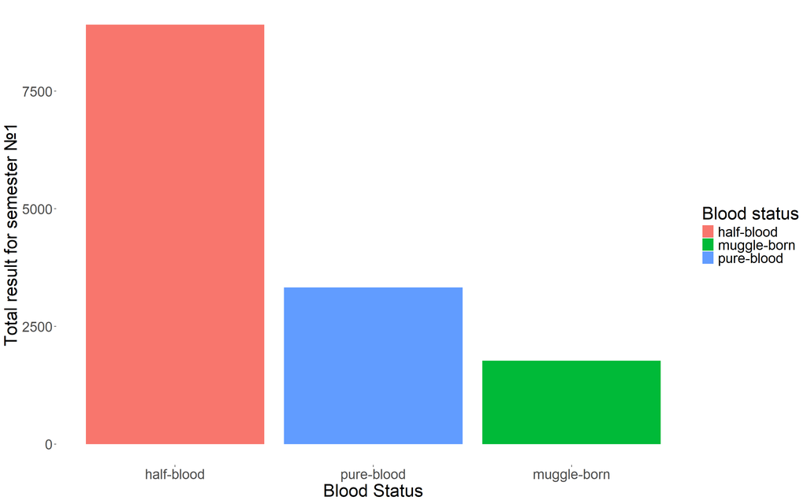

```r
hogwarts %>%
  mutate(sem1_sum = rowSums(across('week_1':'week_17'))) %>%
  group_by(bloodStatus) %>%
  summarize(totalSem1Sum = sum(sem1_sum))%>%
  ggplot()+
  geom_col(aes(x = fct_reorder(bloodStatus, totalSem1Sum, .desc = TRUE), y = totalSem1Sum, fill = bloodStatus))+
  labs(x = 'Blood Status', y = 'Total result for semester №1', fill = 'Blood status')+
 theme_custom
```

**Интерпретация графика:** Можно заметить, что у полукровок общий результат по баллам за первый семестр значительно выше, чем у остальных групп студентов. Это может быть связано с тем, что полукровки “собирают” в себе качества как от волшебников, так и от магглов, что делает их более успешными в обучении. Вторая гипотеза состоит в том, что полукровок просто больше, чем остальных студентов. Поэтому проверим это в следующем задании.

### Задание №2

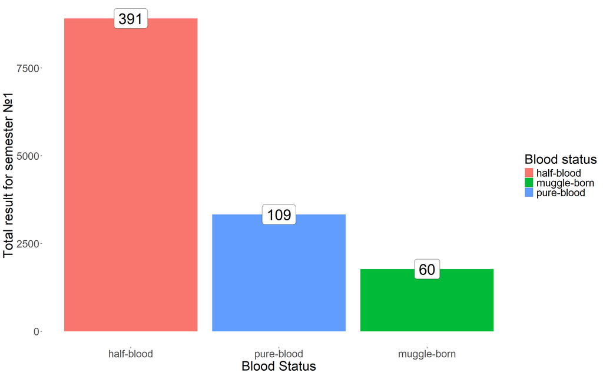

```r
hogwarts %>%
  mutate(sem1_sum = rowSums(across('week_1':'week_17'))) %>%
  group_by(bloodStatus) %>%
  summarize(totalSem1Sum = sum(sem1_sum), count = n())%>%

  ggplot()+
  geom_col(aes(x = fct_reorder(bloodStatus, totalSem1Sum, .desc = TRUE), y = totalSem1Sum, fill = bloodStatus))+
  labs(x = 'Blood Status', y = 'Total result for semester №1', fill = 'Blood status')+
  theme_custom+
  geom_label(aes(x = fct_reorder(bloodStatus, totalSem1Sum, .desc = TRUE),
    y = totalSem1Sum, label = count), size = 10)
```

Интерпретация графика: Можно заметить, что гипотеза подтверждается данной визуализацией. Разрыв в сумме оценок по первому семестру можно объяснить количеством студентов определенной группы. Больше студентов => больше баллов.

### Задание №3

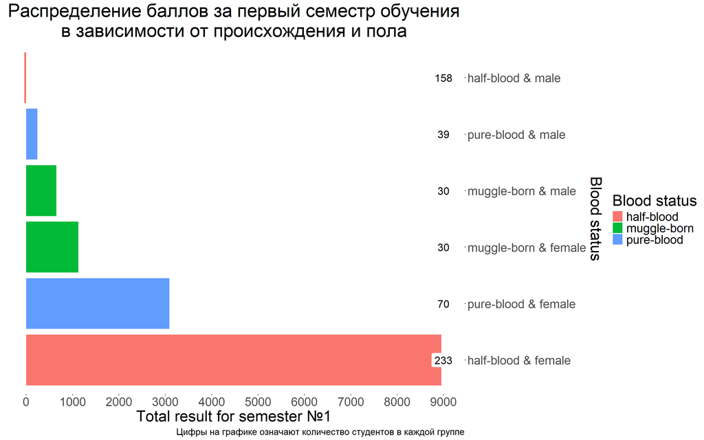

```r
plot3 <- hogwarts %>%
  mutate(sem1_sum = rowSums(across('week_1':'week_17'))) %>%
  group_by(bloodStatus, sex) %>%
  summarize(totalSem1Sum = sum(sem1_sum), count = n())%>%
  mutate(`bloodstatus and sex` = paste0(bloodStatus, " & ", sex)) %>%

  ggplot()+
  geom_col(aes(x = totalSem1Sum, y = fct_reorder(`bloodstatus and sex`, totalSem1Sum, .desc = TRUE), fill = bloodStatus))+
  labs(x = 'Total result for semester №1',
       y = 'Blood status',
       fill = 'Blood status',
       title = 'Распределение баллов за первый семестр обучения\nв зависимости от происхождения и пола',
       caption = 'Цифры на графике означают количество студентов в каждой группе')+
  theme_custom+
  geom_label(
    aes(y = fct_reorder(`bloodstatus and sex`, totalSem1Sum, .desc = TRUE),
        x = 9000, label = count),
    size = 6,
    label.size = 0)+
  scale_x_continuous(breaks = seq(0, 11000, l = 12))+
  scale_y_discrete(position = 'right')


plot3
```

```r
ggsave("bloodstatusandsexSem1results.png", plot3, width = 20, height = 15, dpi = 300, units = "in")
```

### Задание №4

Функция coord_flip() производит смену переменных по осям. Например, если применить её к предыдущему графику:

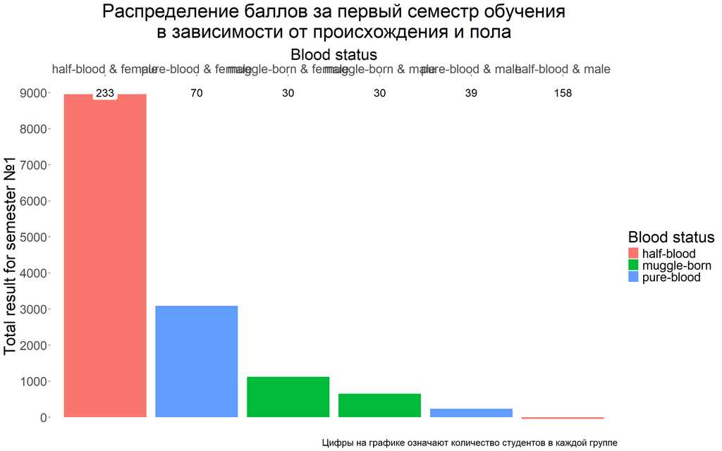

```r
plot3 +
  coord_flip()
```

Видим, что переменные по оси абсцисс и ординат поменялись местами. То есть график “перевернулся”. Это может быть полезно в случае, если в изначальном графике нам не нравится то, как он читается (перекрываются надписи, не интуитивно понятен смысл), возможно, если его перевернуть в более интуитивно понятный вид, то читателю будет яснее, что автор хотел сказать этим графиком.

Однако в данном случае получилось совсем наоборот. При переворачивании - надписи на оси Х стали совсем не читаемые.

Из минусов: данная функция работает не со всеми типами графиков. Она полезна для тех типов geoms, в которых нет настройки orientation.

## Разное

### Задание №1

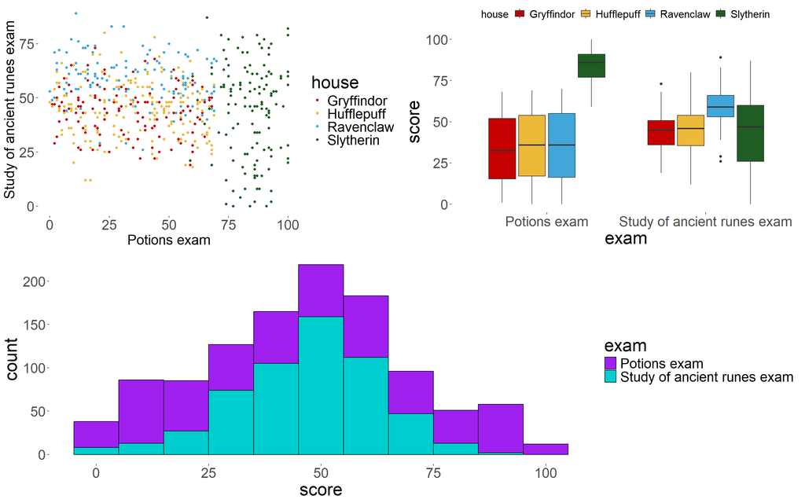

```r
scatter <- hogwarts %>%
  ggplot()+
  geom_point(aes(x = `Study of ancient runes exam`, y = `Potions exam`, color = house))+
  scale_color_manual(values = house_colors)+
  coord_flip()+
  theme_custom+
  theme(axis.title = element_text(size = 20))

boxplot <- hogwarts %>%
  pivot_longer(cols = c(`Potions exam`, `Study of ancient runes exam`), names_to = "exam", values_to = 'score') %>%
  ggplot()+
  geom_boxplot(aes(x = exam, y = score, fill = house))+
  scale_fill_manual(values = house_colors)+
  theme_custom+
  theme (legend.position = 'top',
         legend.title = element_text(size = 15),
         legend.text = element_text(size = 15))

hist <- hogwarts %>%
  pivot_longer(cols = c(`Potions exam`, `Study of ancient runes exam`), names_to = "exam", values_to = 'score') %>%
  ggplot()+
  geom_histogram(aes(x = score, fill = exam), bins = ceiling(log2(nrow(hogwarts)) + 1), color = 'black')+
  scale_fill_manual(values = c('Potions exam'= 'purple',
                               'Study of ancient runes exam' = 'cyan3'))+
  theme_custom

ggarrange(plotlist = list(
  ggarrange(plotlist = list(scatter, boxplot), ncol = 2), hist), nrow = 2
)
```

### Задание №2

```r
data <- hogwarts %>%
  select(bloodStatus, `Potions exam`) %>%
  pivot_longer(cols = `Potions exam`, names_to = 'Potions exam', values_to = 'Score') %>%
  group_by(bloodStatus) %>%
  summarise(Potions_exam_mean = mean(`Score`), sd = sd(`Score`))

graph1 <- data %>%
  ggplot()+
  geom_pointrange(aes(x = fct_relevel(bloodStatus, c("muggle-born", "pure-blood", "half-blood")), y = Potions_exam_mean,
                      ymin = Potions_exam_mean-sd, ymax = Potions_exam_mean+sd,
                      color = bloodStatus), show.legend = FALSE, linewidth = 1)+
  labs(y = "Mean Potions exam result \u00b1 SD",
       x = "Blood status")+
  ylim(0, 100)+
  geom_hline(yintercept = 50, linetype = 'dotdash', linewidth = 1)+
  theme_custom
```

**Наблюдение:** Маглорожденные зарабатывают заметно меньше балло за экзамен по зельеварению, чем остальные группы студентов. Сложно сказать, что статистически значимо меньше, но сейчас не об этом)

**Гипотеза:** Возможно, конкретно по данному предмету существует предвзятость преподавателя к конкретной группе студентов, а именно к маглорожденным. Можно проверить это, посмотрев распределение баллов за весь год.

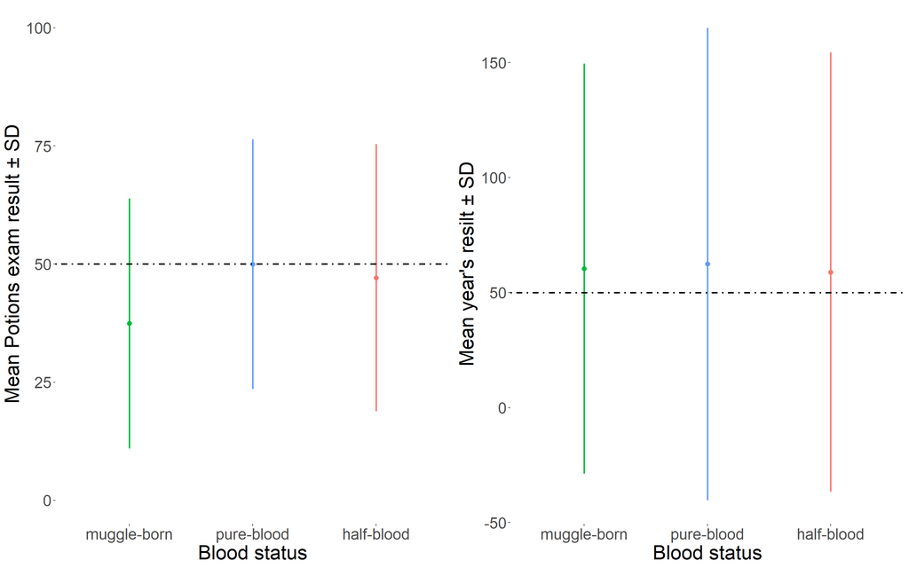

```r
graph2 <- hogwarts %>%
  select(bloodStatus, result) %>%
  group_by(bloodStatus)%>%
  summarise(Result = mean(result), sd = sd(result)) %>%

  ggplot()+
  geom_pointrange(aes(x = fct_relevel(bloodStatus, c("muggle-born", "pure-blood", "half-blood")), y = Result,
                      ymin = Result-sd, ymax = Result+sd,
                      color = bloodStatus), show.legend = FALSE, linewidth = 1)+
  geom_hline(yintercept = 50, linetype = 'dotdash', linewidth = 1)+
  labs(y = "Mean year's resilt \u00b1 SD",
       x = "Blood status")+
  theme_custom

ggarrange(plotlist = list(graph1, graph2))
```

**Интерпретация графика:** Как можно заметить, что среднегодовой результат по группам не особо отличается. Поэтому можно выдвинуть гипотезу, что студенты в зависимости от происхождения не отличаются по умственным способностям и косвенно подтвердить гипотезу о предвзятости преподавателя зельеварения к маглорожденным

P.S. Я действительно хотел попытаться выполнить доп.задание, но посмотрев на его теоретический объем и количество оставшегося у меня времени на другие домашние задания и просмотр пропущенных мной лекций по причине отпуска - вынужден его пропустить(  
Хотел сказать отдельное спасибо за такие продуманные и интересные домашние задания! Представляю, какого труда стоило придумать такой датасет и задания, а также какого труда в настоящий момент проверять и давать такие подробные и обширные комментарии.

Спасибо!